# sfcrime

This is a look at police department statistics from the City of San Francisco for the summer of 2014. The first step is to load up all our libraries and the data set. Then we will explore a little bit to see the lay of the land.

```python
%matplotlib inline
%pylab inline

import matplotlib.pyplot as plt
matplotlib.style.use('ggplot')
import numpy as np
import pandas as pd
```

```python
data = pd.read_csv("sanfrancisco_incidents_summer_2014.csv")
print data.shape
cols = data.columns.tolist()
print cols
```

```
(28993, 13)
['IncidntNum', 'Category', 'Descript', 'DayOfWeek', 'Date', 'Time', 'PdDistrict', 'Resolution', 'Address', 'X', 'Y', 'Location', 'PdId']
```

We can see there are almost 29,000 incidents (not all crimes.)

The more interesting features are perhaps: Category (e.g., "LARCENY"), DayOfWeek (e.g., "MONDAY"), Time (e.g., "14:28"), and PdDistrict (e.g., "TENDERLOIN").

Let's see if some days of the week have more incidents than others:

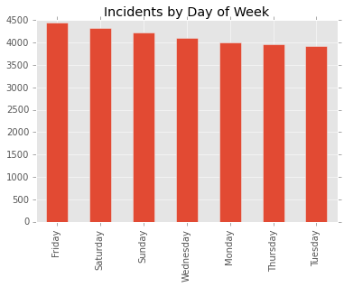

```python
dow = data["DayOfWeek"]
counts = dow.value_counts()
counts.plot(kind="bar", title =  "Incidents by Day of Week")
```

We can see that more incidents occur during the weekend than on workdays. A pie chart would not be appropriate for this data because angles are not perceived as easily as lengths; thus, a bar chart. We can easily see that there are roughly 10% more incidents on Fridays than on Tuesdays. (NB: It is possible that there are more Fridays than Tuesday in the dataset. I should have checked this.)

Now let's look by hour. The time is given in 24-hr format.

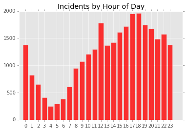

```python
plt.figure()
hour = map(lambda s: int(s.split(":")[0]), data['Time'])
counts = zeros(24)
for hr in hour:
    counts[hr] += 1
plt.title("Incidents by Hour of Day")
plt.bar(range(24), counts, color="r", align="center",alpha=0.8)
plt.xticks(range(24))
plt.xlim([-1, 25])
plt.show()
```

We can see a relatively smooth pattern, except that there is a large bump at the noon hour. It seems possible that 12:00 is inserted as a placeholder in some records, so let's investigate that further. This time we record incidents by minute in the day. There are 24 * 60 = 1440 minutes.

```
1440
```

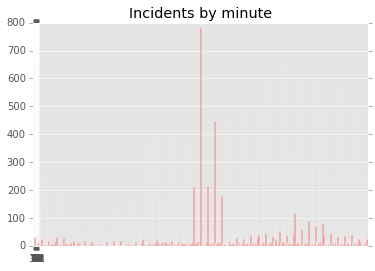

```python
data["Time"]
plt.figure()
def time_in_minutes(s):
    hr, min = s.split(":")
    return int(hr)*60+int(min)

decimal_times = map(time_in_minutes, data['Time'])
minutes_in_day = time_in_minutes("24:00")
print minutes_in_day
counts = zeros(minutes_in_day)
for t in decimal_times:
    counts[t] += 1
plt.title("Incidents by minute")
plt.bar(range(minutes_in_day), counts, color="r", align="center")
plt.xticks(range(24))
plt.xlim([-1, 1441])
plt.show()
```

In fact, there is a large spike at 12:00. About 1 of every 37 incidents is reported at exactly 12 noon, apparently for administrative convenience.

```python
float(shape(data[data["Time"]=="12:00"])[0]) / shape(data)[0]
```

```
0.027041009898941124
```

Now let's see what kinds of incidents are reported disproportionately at exactly 12 noon.

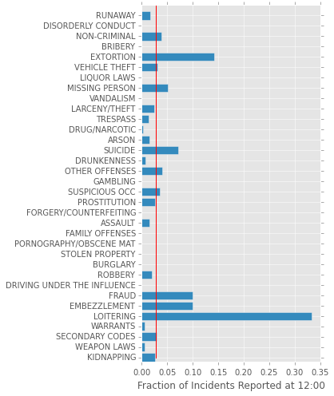

```python
noon = data[data["Time"]=="12:00"]
allcat = data["Category"]
nooncat = noon["Category"]

allcatlist = allcat.values.tolist()
allcount = {s:0 for s in allcatlist}
nooncount = allcount.copy()
for cat in allcat: allcount[cat] += 1
for cat in nooncat: nooncount[cat] += 1
nooncount
for cat in nooncount.keys():
    nooncount[cat] /= float(allcount[cat])
nooncount
crimes = nooncount.keys()
y_pos = np.arange(len(crimes))
pct = nooncount.values()
total_noon_frac = float(shape(data[data["Time"]=="12:00"])[0]) / shape(data)[0]
#plt.set_aspect(10)
plt.figure(1,figsize=(4,8))
plt.barh(y_pos,pct,align="center",alpha=1)
plt.yticks(y_pos,crimes)
plt.xlabel('Fraction of Incidents Reported at 12:00')
plot([total_noon_frac,total_noon_frac],[0,len(crimes)],"r")
plt.show()
```

The white-collar crimes extortion, fraud, and embezzlement seem to be disproportionately reported at noon. It appears that loitering is reported disproportionately at noon; however, there are only three incidents of loitering in the data set. Likewise, there is only one incident of bribery. This plot could be improved by including the total number of each incident. Here is a table of that information.

```python
data["Category"].value_counts()
```

```
LARCENY/THEFT                  9466
OTHER OFFENSES                 3567
NON-CRIMINAL                   3023
ASSAULT                        2882
VEHICLE THEFT                  1966
WARRANTS                       1782
DRUG/NARCOTIC                  1345
SUSPICIOUS OCC                 1300
MISSING PERSON                 1266
SECONDARY CODES                 442
WEAPON LAWS                     354
ROBBERY                         308
TRESPASS                        281
FRAUD                           242
DRUNKENNESS                     147
KIDNAPPING                      117
PROSTITUTION                    112
DRIVING UNDER THE INFLUENCE     100
ARSON                            63
RUNAWAY                          61
LIQUOR LAWS                      42
DISORDERLY CONDUCT               31
FORGERY/COUNTERFEITING           18
VANDALISM                        17
SUICIDE                          14
FAMILY OFFENSES                  10
EMBEZZLEMENT                     10
STOLEN PROPERTY                   8
EXTORTION                         7
BURGLARY                          6
LOITERING                         3
PORNOGRAPHY/OBSCENE MAT           1
GAMBLING                          1
BRIBERY                           1
dtype: int64
```

Next we can look at incidents by district.

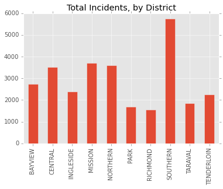

```python
dist = data["PdDistrict"]
counts = dist.value_counts()
counts.sort_index().plot(kind="bar",title="Total Incidents, by District")
```

The pie chart below brings out a different aspect of the by-district statistics. It is not so easy to compare the districts to each other; however, it is easy to compare any district to the whole.

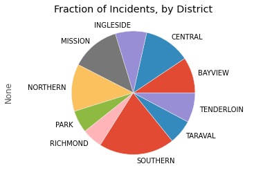

```python
dist = data["PdDistrict"]
counts = dist.value_counts()
plt.axis("equal")
counts.sort_index().plot(kind="pie",title="Fraction of Incidents, by District")
```

Next we can look at incidents of fraud by district, and incidents of prostitution by district.

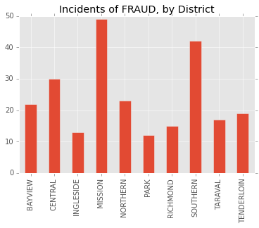

```python
fraud = data[data["Category"]=="FRAUD"]
dist = fraud["PdDistrict"]
counts = dist.value_counts()
counts.sort_index().plot(kind="bar", title="Incidents of FRAUD, by District")
```

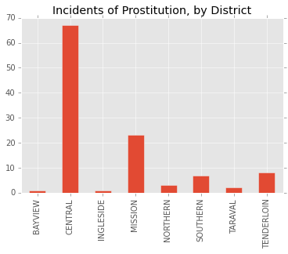

```python
prost = data[data["Category"]=="PROSTITUTION"]
dist = prost["PdDistrict"]
counts = dist.value_counts()
counts.sort_index().plot(kind="bar",title="Incidents of Prostitution, by District")
```

Now let's try to put those side by side.

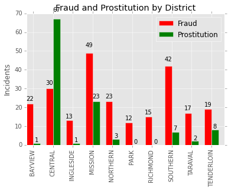

```python
alldist = data["PdDistrict"]
distlist = sorted(alldist.value_counts().keys().tolist())
fraudcounts = {s:0 for s in distlist}
for d in fraud["PdDistrict"]: fraudcounts[d] += 1
fraudcounts = [fraudcounts[d] for d in distlist]
prostcounts = {s:0 for s in distlist}
for d in prost["PdDistrict"]: prostcounts[d] += 1
prostcounts = [prostcounts[d] for d in distlist]

N = len(distlist)

ind = np.arange(N)  # the x locations for the groups
width = 0.35       # the width of the bars

fig, ax = plt.subplots()
rects1 = ax.bar(ind, fraudcounts, width, color='r')

rects2 = ax.bar(ind + width, prostcounts, width, color='g')
# add some text for labels, title and axes ticks
ax.set_ylabel('Incidents')
ax.set_title('Fraud and Prostitution by District')
ax.set_xticks(ind + width)
ax.set_xticklabels(distlist,rotation=90)

ax.legend((rects1[0], rects2[0]), ('Fraud', 'Prostitution'))


def autolabel(rects):
    # attach some text labels
    for rect in rects:
        height = rect.get_height()
        ax.text(rect.get_x() + rect.get_width()/2., 1.05*height,
                '%d' % int(height),
                ha='center', va='bottom')

autolabel(rects1)
autolabel(rects2)

plt.show()
```

We could also explore the relationship between drugs and prostitution by district.

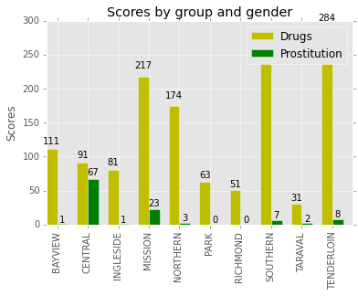

```python
drugs = data[data["Category"]=="DRUG/NARCOTIC"]
alldist = data["PdDistrict"]
distlist = sorted(alldist.value_counts().keys().tolist())
drugscounts = {s:0 for s in distlist}
for d in drugs["PdDistrict"]: drugscounts[d] += 1
drugscounts = [drugscounts[d] for d in distlist]
prostcounts = {s:0 for s in distlist}
for d in prost["PdDistrict"]: prostcounts[d] += 1
prostcounts = [prostcounts[d] for d in distlist]

N = len(distlist)

ind = np.arange(N)  # the x locations for the groups
width = 0.35       # the width of the bars

fig, ax = plt.subplots()
rects1 = ax.bar(ind, drugscounts, width, color='y')

rects2 = ax.bar(ind + width, prostcounts, width, color='g')
# add some text for labels, title and axes ticks
ax.set_ylabel('Scores')
ax.set_title('Scores by group and gender')
ax.set_xticks(ind + width)
ax.set_xticklabels(distlist,rotation=90)

ax.legend((rects1[0], rects2[0]), ('Drugs', 'Prostitution'))


def autolabel(rects):
    # attach some text labels
    for rect in rects:
        height = rect.get_height()
        ax.text(rect.get_x() + rect.get_width()/2., 1.05*height,
                '%d' % int(height),
                ha='center', va='bottom')

autolabel(rects1)
autolabel(rects2)

plt.show()
```

There is no obvious relationship between drug and prostitution incidents. The distinct with the most prostitution incidents is somewhere in the middle for drug incidents. Note a difficulty with this graph: The prostution scale runs only to 67, while the drugs scale approaches 300. A remedy could be to have two scales, one on each side of the chart, to make the heights of the drug bars similar to the prostitution bars.

I hope you have enjoyed looking at my efforts.